# Homework 05

Set a random seed before each simulation question and report it. You may use standard packages unless a question asks you to write the calculation yourself. Use equal neighbor weights throughout. Here $p$ counts the covariates used to measure distance; do not add an intercept column to a KNN predictor matrix. R and Python use different random-number generators, so their exact simulation results need not agree.

## Question 1: Estimate the bias and variance of KNN

In our previous homework, we used repeated simulations to study the behavior of linear regression estimators. We will now use the same idea for KNN. Consider the regression model

$$Y_i=f(\mathbf X_i)+\epsilon_i,
\qquad
f(\mathbf x)=0.5x_1+\sin(x_2)-0.3x_3^2,$$

where the three covariates are independent standard normal variables and $\epsilon_i\sim\mathcal N(0,0.1^2)$ independently of the covariates and other observations. Generate $n=400$ training observations. Our goal is to estimate the mean response at

$$\mathbf x_0=(0.5,0.7,1)^{\mathsf T}.$$

Use Euclidean distance and consider $k=1,3,5,\ldots,29$.

1. Calculate $f(\mathbf x_0)$. Generate one training dataset and obtain the KNN prediction at $\mathbf x_0$ for each value of $k$.

**Show the workflow**

```r
set.seed(43251)
x0 <- c(0.5, 0.7, 1)
k_values <- seq(1, 29, by = 2)
f <- function(x1, x2, x3) 0.5 * x1 + sin(x2) - 0.3 * x3^2

f_x0 <- f(x0[1], x0[2], x0[3])

knn_predict_x0 <- function(X, y, x0, k_values) {
  d <- sqrt(rowSums(sweep(X, 2, x0, "-")^2))
  y_sorted <- y[order(d)]
  sapply(k_values, function(k) mean (y_sorted[1:k]))
}
```

**Show the workflow**

```r
n <- 400

X <- matrix(rnorm(n * 3), nrow = n, ncol = 3)
y <- f(X[, 1], X[, 2], X[, 3]) + rnorm(n, sd = 0.1)

f_x0
```

```
[1] 0.5942177
```

**Show the workflow**

```r
pred_one <- knn_predict_x0(X, y, x0, k_values)
data.frame (k = k_values, prediction = pred_one)
```

```
    k prediction
1   1  0.7888302
2   3  0.6621674
3   5  0.6642853
4   7  0.6100117
5   9  0.6318671
6  11  0.4925114
7  13  0.5222989
8  15  0.5810203
9  17  0.5738171
10 19  0.5751479
11 21  0.5800517
12 23  0.5519177
13 25  0.5214556
14 27  0.4952957
15 29  0.4972667
```

Used the seed 43251. The true mean response at the target point x0 = (0.5, 0.7, 1) is 0.594.

2. Independently repeat the generation of the training covariates and responses 200 times. Within each repetition, use the same training data for every value of $k$. Store the predictions in a matrix with 200 rows and one column for each value of $k$. Use this matrix to estimate the bias, variance, and mean squared error of the estimated mean response. Use divisor 200 when calculating the empirical variance, and verify numerically that

$$\text{mean squared error}
=\text{squared bias}+\text{variance}.$$

Plot squared bias, variance, and mean squared error against $k$ in one figure. Explain the pattern and compare it with the bias-variance trade-off for ridge regression or lasso.

**Show the workflow**

```r
n_sim <- 200
pred_matrix <- matrix(NA, nrow = n_sim, ncol = length(k_values))

for (i in 1:n_sim) {
  X <- matrix(rnorm(n * 3), nrow = n, ncol = 3)
  y <- f(X[, 1], X[, 2], X[, 3]) + rnorm(n, sd = 0.1)
  pred_matrix[i, ] <- knn_predict_x0(X, y, x0, k_values)
}

bias <- colMeans(pred_matrix) - f_x0
variance <- colMeans((sweep(pred_matrix, 2, colMeans(pred_matrix), "-"))^2)
mse <- colMeans((pred_matrix - f_x0)^2)

all.equal(mse, bias^2 + variance)
```

```
[1] TRUE
```

**Show the workflow**

```r
results <- data.frame(k = k_values, bias2 = bias^2, variance = variance, mse = mse)
results
```

```
    k        bias2    variance        mse
1   1 1.559809e-06 0.037181204 0.03718276
2   3 8.621083e-04 0.019831580 0.02069369
3   5 1.665924e-03 0.014731018 0.01639694
4   7 2.078424e-03 0.010865566 0.01294399
5   9 2.690197e-03 0.009467440 0.01215764
6  11 3.888882e-03 0.009506180 0.01339506
7  13 4.596549e-03 0.009397702 0.01399425
8  15 4.993226e-03 0.008542311 0.01353554
9  17 6.642228e-03 0.008213727 0.01485595
10 19 7.989793e-03 0.008429774 0.01641957
11 21 9.231515e-03 0.008413451 0.01764497
12 23 1.056859e-02 0.008103017 0.01867161
13 25 1.163117e-02 0.008091147 0.01972232
14 27 1.309385e-02 0.007777947 0.02087180
15 29 1.480802e-02 0.007474576 0.02228259
```

**Show the workflow**

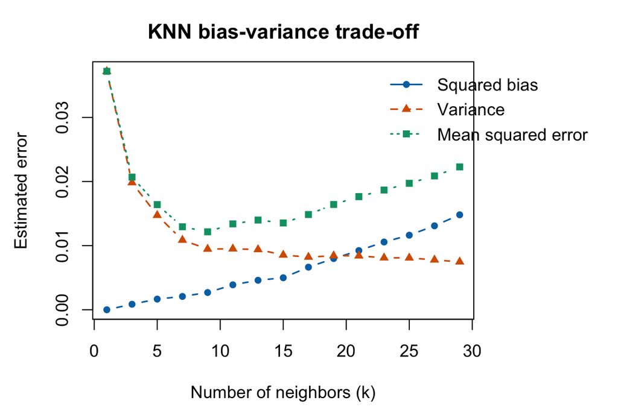

```r
plot_values <- cbind(bias^2, variance, mse)
plot_colors <- c("#0072B2", "#D55E00", "#009E73")
plot_labels <- c("Squared bias", "Variance", "Mean squared error")

op <- par(mar = c(4.5, 4.5, 3, 7), xpd = NA)
matplot(
  k_values, plot_values,
  type = "b", pch = c(16, 17, 15), col = plot_colors,
  lty = c(1, 2, 3), lwd = 1.5, cex = 0.9,
  xlab = "Number of neighbors (k)", ylab = "Estimated error",
  main = "KNN bias-variance trade-off"
)
legend(
  "topright", inset = c(-0.32, 0), bty = "n",
  legend = plot_labels, col = plot_colors,
  pch = c(16, 17, 15), lty = c(1, 2, 3), lwd = 1.5,
  pt.cex = 0.9, y.intersp = 1.2
)
```

**Show the workflow**

```r
par(op)
```

A small k acts as a small penalty and a large k acts as a large penalty. This is similar to the bias-variance tradeoff of LASSO and ridge regression, except the penalty isn’t applied to the coeffcieints in KNN. Instead, the penalty is applied to the number of neighbors used in a prediction. A small k allows for a more flexible model, while a large k forces the model to be more rigid.

## Question 2: Compare KNN with lasso

Use the response model from Question 1, including the noise standard deviation $0.1$, but generate $p=30$ covariates. The response still depends only on the first three. Consider these two settings:

- **Setting 1:** all 30 covariates are independent standard normal variables.
- **Setting 2:** the covariates have a multivariate normal distribution with mean zero and covariance matrix $\boldsymbol\Sigma$, where

  $$\Sigma_{jj}=1,
  \qquad
  \Sigma_{jl}=0.8\quad\text{for }j\ne l.$$

In each setting, generate 400 training observations and 1,000 independent test observations. Fit 5NN using Euclidean distance on the supplied covariate scale. All covariates already have population variance one.

For lasso, use a linear model containing the 30 covariates and a separately fitted, unpenalized intercept. Follow the Week 4 objective,

$$L_\lambda(\boldsymbol\beta)
=\frac{1}{2n}\left\lVert
\widetilde{\mathbf y}-\mathbf X\boldsymbol\beta
\right\rVert_2^2
+\lambda\lVert\boldsymbol\beta\rVert_1,$$

where $\mathbf X\in\mathbb R^{n\times30}$ contains the centered and standardized covariates and $\widetilde{\mathbf y}$ is the centered training response. Select the penalty by ten-fold cross-validation over 41 logarithmically spaced values from $10^{-4}$ to $1$. Estimate all means and scales using only the training portion of each fold, with divisor equal to that portion’s sample size. After selecting the penalty, refit on all training observations and apply the fitted transformations unchanged to the test observations. Do not add nonlinear terms to the lasso model.

1. Fit both methods in each setting. Use the same training and test data for the two methods within a setting. Report their test MSE values in one table, together with the selected lasso penalty and the number of nonzero lasso slopes. You only need to generate one dataset for each setting; repeated simulations are not required.

Used AI for this code.

**Show the workflow**

```r
library(glmnet)
```

**Show the workflow**

```r
set.seed(43252)

n_train <- 400
n_test <- 1000
p <- 30
lambda_grid <- 10^seq(-4, 0, length.out = 41)
lambda_dec <- sort(lambda_grid, decreasing = TRUE)

f <- function(X) 0.5 * X[, 1] + sin(X[, 2]) - 0.3 * X[, 3]^2

# Setting 1: independent covariates.
# Setting 2: pairwise correlation 0.8, built from one shared factor
# plus independent noise for each covariate.
gen_X <- function(n, setting) {
  if (setting == 1) {
    matrix(rnorm(n * p), nrow = n, ncol = p)
  } else {
    common <- rnorm(n)
    sqrt(0.8) * matrix(common, nrow = n, ncol = p) +
      sqrt(0.2) * matrix(rnorm(n * p), nrow = n, ncol = p)
  }
}

gen_data <- function(setting) {
  Xtr <- gen_X(n_train, setting)
  ytr <- f(Xtr) + rnorm(n_train, sd = 0.1)
  Xte <- gen_X(n_test, setting)
  yte <- f(Xte) + rnorm(n_test, sd = 0.1)
  list(Xtr = Xtr, ytr = ytr, Xte = Xte, yte = yte)
}

# 5NN with Euclidean distance on the supplied scale
knn_predict <- function(Xtr, ytr, Xte, k = 5) {
  d2 <- outer(rowSums(Xte^2), rowSums(Xtr^2), "+") - 2 * Xte %*% t(Xtr)
  apply(d2, 1, function(row) mean(ytr[order(row)[1:k]]))
}

# Lasso: means and scales come only from the data passed to each fit
standardize_fit <- function(X) {
  list(mean = colMeans(X),
       sd = apply(X, 2, function(col) sqrt(mean((col - mean(col))^2))))
}
apply_std <- function(X, st) sweep(sweep(X, 2, st$mean, "-"), 2, st$sd, "/")

fit_lasso <- function(X, y, lambdas) {
  st <- standardize_fit(X)
  Xs <- apply_std(X, st)
  fit <- glmnet(Xs, y - mean(y), alpha = 1, lambda = lambdas, family = gaussian(),
                standardize = FALSE, intercept = FALSE,
                control = list(thresh = 1e-14, maxit = 1000000))
  list(beta = as.matrix(fit$beta), st = st, ybar = mean(y))
}

predict_lasso <- function(obj, Xnew) {
  obj$ybar + apply_std(Xnew, obj$st) %*% obj$beta
}

cv_lasso <- function(X, y, lambdas, K = 10) {
  folds <- sample(rep(1:K, length.out = nrow(X)))
  err <- matrix(NA, nrow = K, ncol = length(lambdas))
  for (fold in 1:K) {
    idx <- folds == fold
    obj <- fit_lasso(X[!idx, , drop = FALSE], y[!idx], lambdas)
    pred <- predict_lasso(obj, X[idx, , drop = FALSE])
    err[fold, ] <- colMeans((y[idx] - pred)^2)
  }
  colMeans(err)
}

run_setting <- function(setting) {
  dat <- gen_data(setting)
  knn_mse <- mean((dat$yte - knn_predict(dat$Xtr, dat$ytr, dat$Xte, k = 5))^2)
  cv_err <- cv_lasso(dat$Xtr, dat$ytr, lambda_dec)
  best <- which.min(cv_err)
  obj <- fit_lasso(dat$Xtr, dat$ytr, lambda_dec[best])
  lasso_mse <- mean((dat$yte - predict_lasso(obj, dat$Xte))^2)
  data.frame(setting = setting, knn_mse = knn_mse, lasso_mse = lasso_mse,
             lasso_lambda = lambda_dec[best], nonzero_slopes = sum(abs(obj$beta) > 1e-8))
}

results <- rbind(run_setting(1), run_setting(2))
results
```

```
  setting   knn_mse lasso_mse lasso_lambda nonzero_slopes
1       1 0.5681199 0.2866887   0.03981072              5
2       2 0.1799867 0.2321411   0.01584893              8
```

Used seed 43252. The numbers are in order of knn_mse, lasso_mse, lasso_lambda, nonzero_slopes. Setting 1 has the results of 0.568, 0.287, 0.0398, 5. Setting 2 has the results of 0.18, 0.232, 0.0158, 8.

2. Compare the results between the two settings. Explain how correlation can change the usefulness of Euclidean neighborhoods, and why lasso does not use all covariates in the same way as KNN.

KNN improved a lot from setting 1 to setting 2 because the test mse falls from 0.568 to 0.18 while the lasso mse didn’t fall that much. We conclude with correlated covariates, KNN is the better method.

When covariates are correlated, the Euclidean distance between observations may not accurately reflect their similarity in terms of the underlying relationship with the response variable. This is because correlated covariated are largely affected by the same factor, whereas independent covariates, many of them do not have anything to do with the response variable.

Lasso does not use all covariates in the same way as KNN because KNN gives all the covariates equal weight in the distance and doesn’t look at the response when choosing neighbors. Lasso uses the response to learn a weight for each covariate so it can drop irrelevant covariates. In our example, the Lasso nonzero slopes are 5 and 8 for the two settings, which is significantly less than the 30 covariates available.

3. The response model contains $\sin(X_2)$ and $X_3^2$, but the lasso fit uses only linear terms. Explain how this difference affects the comparison. Would the results justify a general claim that correlation always helps KNN, or that one method is always better? Explain why.

The lasso fit uses only linear terms, which means it cannot capture the nonlinear relationships present in the true response model, specifically the $\sin(X_2)$ and $X_3^2$ terms. This limitation can lead to a poorer fit and higher test MSE for lasso compared to KNN, which can adapt to nonlinear relationships through its local averaging of neighbors.

These results would not justify a general claim that correlation always helps KNN or that one method is always better. Things like the choice of k and correlation level can affect the performance of KNN. A truly linear response would heavily favor lasso, and a correlation structure that spreads the signal across many directions instead of one shared facor could hurt KNN rather than help. The comparison shows that the outcome depends on the interaction between model form and the geometry of the covariates.

## Question 3: Observed dimension and latent dimension

The lecture’s handwritten digit example shows that KNN can work with many measured covariates. We will use a simulation to investigate why the structure of those covariates matters.

Let $p=100$ be the number of observed covariates and let $m$ be the number of latent variables. For each observation, generate

$$\mathbf X_i=\mathbf A\mathbf Z_i+\boldsymbol\eta_i,
\qquad
Y_i=Z_{i1}+Z_{i2}+\epsilon_i,$$

where $\mathbf A\in\mathbb R^{100\times m}$ has independent entries from Uniform$[-2,2]$. The entries of $\mathbf Z_i\in\mathbb R^m$ and $\boldsymbol\eta_i\in\mathbb R^{100}$, and the scalar $\epsilon_i$, are independent standard normal variables, also independent of $\mathbf A$. Generate $\mathbf A$ once and use it for all training and test observations in that dataset.

Compare $m=3$ and $m=30$. In each setting, generate 200 training observations and 200 independent test observations. Fit KNN using only the 100 observed covariates in $\mathbf X$, with Euclidean distance on their generated scale. The latent variables in $\mathbf Z$ are used to generate the data but are not available to the fitted model. Consider $k=2,10,18,\ldots,82$.

**Show the workflow**

```r
set.seed(43253)

p <- 100
n_train <- 200
n_test <- 200
k_values <- seq(2, 82, by = 8)
m_values <- c(3, 30)

gen_data <- function(m) {
  A <- matrix(runif(p * m, -2, 2), nrow = p, ncol = m)
  make_part <- function(n) {
    Z <- matrix(rnorm(n * m), nrow = n, ncol = m)
    eta <- matrix(rnorm(n * p), nrow = n, ncol = p)
    X <- Z %*% t(A) + eta
    y <- Z[, 1] + Z[, 2] + rnorm(n)
    list(X = X, y = y)
  }
  list(train = make_part(n_train), test = make_part(n_test))
}

knn_test_mse <- function(dat, k_values) {
  Xtr <- dat$train$X; ytr <- dat$train$y
  Xte <- dat$test$X;  yte <- dat$test$y
  d2 <- outer(rowSums(Xte^2), rowSums(Xtr^2), "+") - 2 * Xte %*% t(Xtr)
  sq_err <- sapply(1:nrow(Xte), function(i) {
    y_sorted <- ytr[order(d2[i, ])]
    cum_mean <- cumsum(y_sorted) / seq_along(y_sorted)
    (yte[i] - cum_mean[k_values])^2
  })
  rowMeans(sq_err)
}
```

1. Generate one dataset for each value of $m$. Fit KNN for every value of $k$ and calculate test MSE. Within a setting, use the same training and test observations for all values of $k$.

**Show the workflow**

```r
part_a <- sapply(m_values, function(m) knn_test_mse(gen_data(m), k_values))
part_a <- data.frame(k = k_values, part_a)
names(part_a) <- c("k", "m = 3", "m = 30")
part_a
```

```
    k    m = 3   m = 30
1   2 1.616037 2.886051
2  10 1.150969 2.039612
3  18 1.158512 1.937517
4  26 1.243143 2.005487
5  34 1.282643 2.010436
6  42 1.353455 2.080082
7  50 1.404378 2.053680
8  58 1.447303 2.096999
9  66 1.505601 2.123024
10 74 1.553983 2.160892
11 82 1.594276 2.175537
```

2. Repeat the complete experiment 50 times, generating a new $\mathbf A$ and new observations in each repetition. Plot average test MSE against $k$, with one curve for each value of $m$. These curves compare the specified choices of $k$ in a controlled simulation; they are not a cross-validation procedure for selecting a final model.

**Show the workflow**

```r
n_rep <- 50
mse_array <- array(NA, dim = c(n_rep, length(k_values), length(m_values)))

for (r in 1:n_rep) {
  for (mi in seq_along(m_values)) {
    mse_array[r, , mi] <- knn_test_mse(gen_data(m_values[mi]), k_values)
  }
}

avg_mse <- apply(mse_array, c(2, 3), mean)
part_b <- data.frame(k = k_values, avg_mse)
names(part_b) <- c("k", "m = 3", "m = 30")
part_b
```

```
    k    m = 3   m = 30
1   2 1.692502 3.095957
2  10 1.293818 2.377554
3  18 1.306429 2.342746
4  26 1.347244 2.366024
5  34 1.404458 2.400012
6  42 1.458697 2.432316
7  50 1.514072 2.465293
8  58 1.570372 2.496053
9  66 1.629384 2.524685
10 74 1.688785 2.553939
11 82 1.749112 2.581968
```

**Show the workflow**

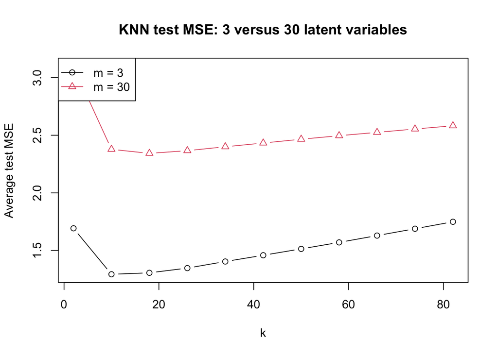

```r
matplot(k_values, avg_mse, type = "b", pch = 1:2, col = 1:2, lty = 1,
        xlab = "k", ylab = "Average test MSE",
        main = "KNN test MSE: 3 versus 30 latent variables")
legend("topleft", legend = c("m = 3", "m = 30"), col = 1:2, pch = 1:2, lty = 1)
```

3. Both settings have 100 observed covariates, and the response depends on only two latent variables. Explain why their KNN performance can still differ. What role does the noise $\boldsymbol\eta_i$ play, and why are the observed data not confined exactly to an $m$-dimensional linear space?

The two settings have the same number of observed covariates (100) and the same response, which depends on only two latent variables, yet KNN does much better when m = 3. What matters is not the number of measured covariates but how many latent directions the observed covariates vary along. KNN measures similarity using all 100 coordinates of X, so two observations are near each other when their whole latent vectors are near each other. When m = 3, being close in X means being close in three latent variables, and two of those are exactly the ones that determine Y, so the neighbors have similar responses. When m = 30, being close in X requires being close in 30 latent variables, and 28 of them have nothing to do with Y. With only 200 training points, the nearest neighbors are far apart in the 30-dimensional latent space, so they are typically not close in the two variables that matter, and the neighbors’ responses differ from the target. This is the curse of dimensionality operating on the latent dimension: the data have a hidden lower-dimensional structure, and how low that dimension is determines how well local averaging works.

The noise eta plays two roles. First, it adds independent variation in all 100 coordinates, so the squared distance between any two observations contains a large noise contribution (about 200 on average, from 100 coordinates with variance 1 each for two observations) that has nothing to do with Y. This blurs the distance and makes the nearest neighbors less reliable, in both settings. Second, it means the observed data are not confined exactly to an m-dimensional linear space. Without eta, every X would be exactly A Z, a combination of the m columns of A, and would lie precisely in an m-dimensional linear subspace of the 100-dimensional space. With eta, each X is displaced off that subspace by independent noise in every one of the 100 directions, so the data lie near the m-dimensional subspace but fill a small band of thickness one around it in all the remaining directions. The signal is much larger than the noise along the m latent directions, so the low-dimensional structure is still visible in the data, and that is why KNN can work in the m = 3 case, but it is not exact, and the noise directions add distance without adding information about Y.

## Question 4: Classify handwritten digits

Use `zip.train` and `zip.test` from the R package `ElemStatLearn`, as in the lecture. The package has been retired from the active CRAN repository. If needed, install the [archived package](https://cran.r-project.org/src/contrib/Archive/ElemStatLearn/ElemStatLearn_2015.6.26.2.tar.gz) into your usual R library, then load the two datasets. Python users can use the course copies of the same [training data](https://teazrq.github.io/stat432rpy/data/knn/zip-train.csv.gz) and [test data](https://teazrq.github.io/stat432rpy/data/knn/zip-test.csv.gz). These compressed CSV files have no headers and are included in the homework ZIP under `data/knn`. Run the Python code from the folder containing `data`.

Each image has $16\times16=256$ pixel values. The first column is the digit label and the remaining columns are the pixel values. Use the first 1,000 rows of `zip.train` and the first 500 rows of `zip.test`. Use the original pixel values without standardization, and do not include the digit label in a distance calculation.

For a test image $\mathbf x_0$ and a training image $\mathbf x_i$, the two distances are

$$d_E(\mathbf x_0,\mathbf x_i)
=\sqrt{\sum_{j=1}^{256}(x_{0j}-x_{ij})^2},
\qquad
d_M(\mathbf x_0,\mathbf x_i)
=\sum_{j=1}^{256}|x_{0j}-x_{ij}|.$$

**Show the workflow**

```r
train_raw <- read.csv("data/knn/zip-train.csv.gz", header = FALSE)
test_raw  <- read.csv("data/knn/zip-test.csv.gz", header = FALSE)

train_y <- train_raw[1:1000, 1]
train_X <- as.matrix(train_raw[1:1000, -1])
test_y  <- test_raw[1:500, 1]
test_X  <- as.matrix(test_raw[1:500, -1])

dim(train_X)
```

```
[1] 1000  256
```

**Show the workflow**

```r
dim(test_X)
```

```
[1] 500 256
```

1. Write a 5NN classification function that allows either Euclidean or Manhattan distance. For each test image, calculate its distances to the training images directly, find the five nearest, and return the most frequent digit label. Break distance ties by the smaller training row number and voting ties by the smallest digit. Do not use a built-in distance or KNN function for this part.

**Show the workflow**

```r
knn5_classify <- function(train_X, train_y, test_X, distance = "euclidean", k = 5) {
  preds <- integer(nrow(test_X))
  for (i in 1:nrow(test_X)) {
    diffs <- sweep(train_X, 2, test_X[i, ], "-")
    d <- if (distance == "euclidean") sqrt(rowSums(diffs^2)) else rowSums(abs(diffs))
    nearest <- order(d)[1:k]   # order() keeps tied distances in original row order
    votes <- table(factor(train_y[nearest], levels = 0:9))
    preds[i] <- as.integer(names(votes)[which.max(votes)])   # first max = smallest digit
  }
  preds
}
```

The classifier computes the Euclidean distance or the Manhattan distance from a test image to all 1,000 training images, takes the five nearest, and returns the most frequent label among them. Distance ties are broken by the smaller training row number, and voting ties by the smallest digit. The first 1,000 rows of zip.train and the first 500 rows of zip.test were used, with the original pixel values and no standardization.

2. Apply the classifier to all 500 test images using each distance. For each fit, report the test classification error and a $10\times10$ confusion matrix, with rows representing predicted digits and columns representing true digits. Keep all digit labels from 0 through 9 in the matrix, including any with a zero count. Which digits are most often confused with one another?

**Show the workflow**

```r
pred_E <- knn5_classify(train_X, train_y, test_X, "euclidean")
pred_M <- knn5_classify(train_X, train_y, test_X, "manhattan")

err_E <- mean(pred_E != test_y)
err_M <- mean(pred_M != test_y)
err_E
```

```
[1] 0.122
```

**Show the workflow**

```r
err_M
```

```
[1] 0.138
```

**Show the workflow**

```r
conf_E <- table(Predicted = factor(pred_E, levels = 0:9), True = factor(test_y, levels = 0:9))
conf_M <- table(Predicted = factor(pred_M, levels = 0:9), True = factor(test_y, levels = 0:9))
conf_E
```

```
         True
Predicted   0   1   2   3   4   5   6   7   8   9
        0 118   0   7   1   0   4   2   0   2   0
        1   0  66   0   0   2   0   0   0   0   1
        2   0   0  39   1   0   0   2   0   0   1
        3   0   0   0  23   0   4   0   0   2   0
        4   0   0   1   0  27   1   1   1   0   1
        5   0   0   0   1   0  13   0   0   0   0
        6   0   2   0   0   0   1  41   0   2   0
        7   0   0   0   0   1   1   0  34   0   4
        8   0   0   3   2   0   2   0   0  37   0
        9   1   0   0   1   4   0   0   1   1  41
```

**Show the workflow**

```r
conf_M
```

```
         True
Predicted   0   1   2   3   4   5   6   7   8   9
        0 118   0   6   1   0   5   3   0   4   0
        1   0  67   2   0   2   0   1   0   0   1
        2   0   0  35   0   0   0   2   0   0   0
        3   0   0   1  24   0   4   0   0   2   0
        4   0   0   1   1  27   1   0   1   0   1
        5   0   0   0   1   0  11   0   0   0   0
        6   0   1   0   0   0   2  40   0   2   0
        7   0   0   2   1   1   0   0  34   0   5
        8   0   0   2   0   0   3   0   0  34   0
        9   1   0   1   1   4   0   0   1   2  41
```

Test classification error with Euclidean distance was 0.122 (61 of 500 images wrong), and with Manhattan distance it was 0.138 (69 of 500 wrong). The confusion matrices, with predicted digits in rows and true digits in columns, are shown above and include all digits 0 through 9.

The most common confusion for Euclidean distance was true 2 predicted as 0 (7 times), followed by four confusions with 4 cases each: true 5 predicted as 0, true 5 predicted as 3, true 4 predicted as 9, and true 9 predicted as 7. True 2 predicted as 8 came next (3 times). Manhattan distance shows a similar pattern: true 2 predicted as 0 (6 times), true 9 predicted as 7 and true 5 predicted as 0 (5 times each), then true 5 predicted as 3, true 4 predicted as 9, and true 8 predicted as 0 (4 times each). Digit 5 is the hardest digit for both methods, with only 13 of its 26 test images classified correctly under Euclidean distance and 11 under Manhattan distance. The confused pairs are digits whose handwritten shapes overlap: 4 and 9 share a similar upper part, 9 and 7 share a vertical stroke with a top bar, 5 and 3 share a similar lower curve, and 2 and 0 can both be drawn with a large rounded loop.

3. For Euclidean distance, display three incorrectly classified test images, together with their true and predicted labels. Comment on whether the mistakes are visually understandable. Compare the overall results of the two distance measures. Can they have similar total error while making mistakes on different images? Use your predictions to support your answer.

**Show the workflow**

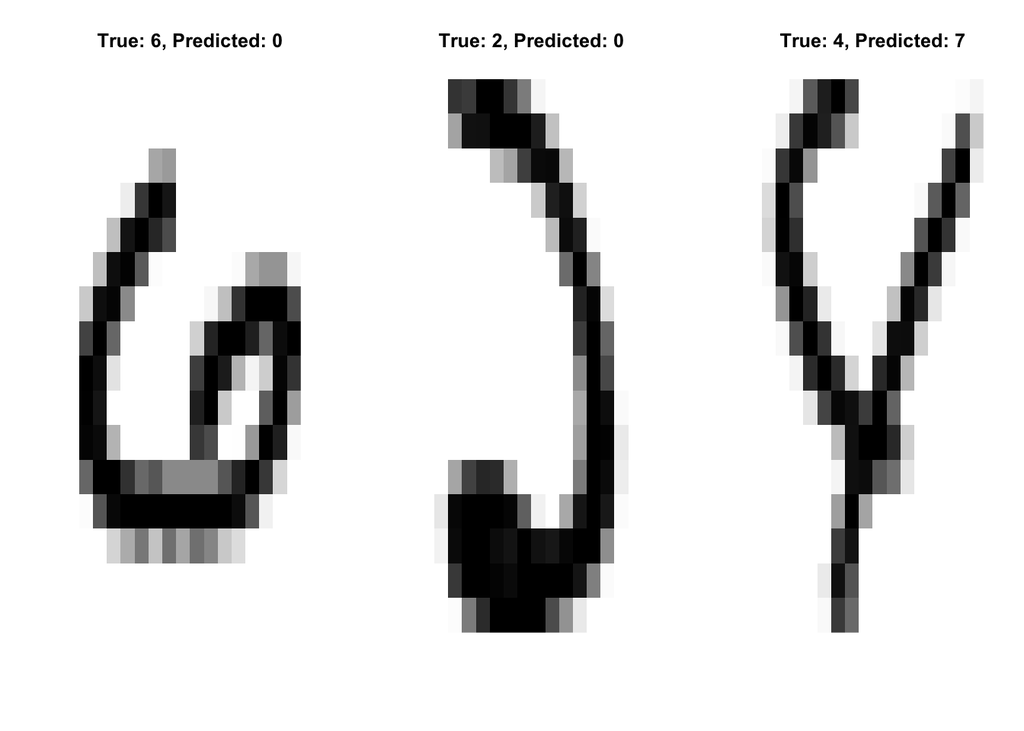

```r
wrong_idx <- which(pred_E != test_y)
show <- wrong_idx[1:3]

par(mfrow = c(1, 3))
for (i in show) {
  m <- matrix(test_X[i, ], nrow = 16, ncol = 16, byrow = TRUE)
  image(t(m)[, 16:1], col = gray(seq(1, 0, length.out = 256)), axes = FALSE,
        main = paste0("True: ", test_y[i], ", Predicted: ", pred_E[i]))
}
```

**Show the workflow**

```r
par(mfrow = c(1, 1))


wrong_E <- pred_E != test_y
wrong_M <- pred_M != test_y
c(both_wrong = sum(wrong_E & wrong_M),
  only_euclidean_wrong = sum(wrong_E & !wrong_M),
  only_manhattan_wrong = sum(!wrong_E & wrong_M),
  neither_wrong = sum(!wrong_E & !wrong_M))
```

```
          both_wrong only_euclidean_wrong only_manhattan_wrong
                  58                    3                   11
       neither_wrong
                 428
```

**Show the workflow**

```r
sum(pred_E != pred_M)
```

```
[1] 22
```

**Show the workflow**

```r
data.frame(test_row = show, true = test_y[show], predicted = pred_E[show])
```

```
  test_row true predicted
1        4    6         0
2       13    2         0
3       14    4         7
```

The three misclassified images shown above have true labels 6, 2 and 4, and were predicted as 0, 0 and 7. Each pairing is understandable. A 6 has a rounded loop in its lower half, so if the upper stroke is short or faint, the image looks like a 0. A 2 written with a large rounded curve and a weak bottom stroke can look like a 0 as well, and this was also the most common confusion in the Euclidean confusion matrix (true 2 predicted as 0, 7 times). A 4 with an open top, or one where the diagonal stroke is more prominent than the vertical one, can look like a 7. Most of these mistakes are ones a person reading messy handwriting could also make. The neighbors are genuinely similar in pixel space, but similar pixel patterns do not always mean the same digit.

The two distances can have similar total error while making mistakes on different images, and in this run they do. Euclidean distance had 61 errors and Manhattan distance had 69, a difference of 8 images or 1.6 percentage points. But the two classifiers gave different predictions on 22 of the 500 test images. Of the 61 Euclidean errors, 58 were also Manhattan errors, 3 were Euclidean-only errors, and 11 were Manhattan-only errors, so 14 images were misclassified by exactly one of the two distances. The other 8 disagreements were images that both classifiers got wrong but with different predicted digits. So similar total error does not mean the same mistakes: the two distances rank the neighbors differently, because Euclidean distance squares each pixel difference and so weights a few large pixel differences more heavily, while Manhattan distance weights all pixel differences in proportion to their size. A different set of five neighbors can produce a different vote for an individual image even when the overall error rate comes out close. With only 500 test images, the 8-image gap between the two methods is small enough that I would not claim Euclidean distance is better in general from this one comparison.

## Question 5: Create a plot-formatting skill

Create a short `SKILL.md` file for improving the formatting of STAT 432 homework plots. You may use AI to help write it.

1. Include a title, a description, and a few formatting rules. The description should limit the skill to STAT 432 homework plot improvements and require an explicit request to use it. Your rules should address margins, titles, axes, labels, colors, and sizes for plots produced in R or Python. Keep them portable: do not refer to specific homework questions.
2. Ask your agent to install the skill. Explicitly call it to improve the plot from Question 1, then compare the original and revised versions. Do you like the changes? You may revise the skill and test it a couple more times, or uninstall it if it remains unhelpful.

I saved the skill as plot-format/SKILL.md and asked Copilot Chat to use it on the Question 1 plot (squared bias, variance and mean squared error against k). The original plot used default formatting with generic axis labels, no title, and colors that were harder to tell apart. The revised plot has a short title, descriptive axis labels (“Number of neighbors (k)” and “Estimated error”), colorblind-friendly colors combined with different line types and point shapes, a 6 by 4 inch size, extra margins so nothing is clipped, and a legend moved outside the plotting region so it does not cover the curves. The agent did not change the data or the plotted quantities, which is what my first rule required. I liked the changes: the plot is easier to read and still readable in grayscale. One thing it did not address is the font size rule, since its list of changes does not mention text size, so a possible revision would be to make that rule more specific about setting a larger base font. I did not need to revise the skill for this test.

3. Append your final `SKILL.md` content to your submission and briefly explain your choices and experience.

## plot-format skill

```markdown
---
name: plot-format
description: Use this skill only when explicitly asked to improve the formatting of a STAT 432 homework plot. It reviews and revises how a plot looks, without changing the data, the analysis, or the conclusions.
---

# plot-format

Apply this skill only when the user explicitly asks for it by name to improve a STAT 432 homework plot. Do not use it for any other task or apply it unprompted.

Rules for plots made in R or Python:

1. Change formatting only. Do not change the data, the computed quantities, the random seed, or the meaning of the plot. If a formatting fix would change what is shown, say so and ask first.
2. Title: give the plot a short title that says what is plotted, with no more than about 10 words.
3. Axes: label both axes in plain words with units or scale when relevant (for example "log(lambda)", "Test MSE"). Do not leave default labels such as "x" or "y" or raw variable names. Keep axis ranges wide enough that no curve or point is cut off.
4. Legend and labels: when there is more than one line or group, include a legend that does not cover the data, using readable names instead of variable names.
5. Colors: use a small set of clearly distinguishable colors, and also vary line type or point shape so the plot stays readable in grayscale or for color-blind readers. Use the same color for the same quantity across all plots in a report.
6. Sizes: make text large enough to read when the plot is shrunk to fit a page (base font size at least 11 points). Use line widths of about 1.5 or more and point sizes that are visible without hiding overlapping points.
7. Margins and layout: leave enough margin that titles, axis labels and tick labels are not clipped. Use a sensible aspect ratio, around 6 by 4 inches for a single plot, and avoid extra empty space.
8. Report back: after revising, list each formatting change you made in one short line each, and show the revised code so the student can read and re-run it.
```

I limited the skill to explicit requests for STAT 432 homework plots so it would not change plots or other work unprompted. The first rule restricts it to formatting changes so it cannot alter the data or analysis, which matters because the goal is a better-looking plot, not a different result. The remaining rules cover the items the assignment asked for (titles, axes, labels, colors, sizes and margins) in general terms that work in R or Python and do not refer to any specific question. I added the rule about using both color and line type or shape so plots stay readable when printed in black and white, and I added a final rule asking the agent to list what it changed, so I can check the revision instead of trusting it blindly.

In my test on the Question 1 plot, Copilot followed the skill: it kept the plotted quantities unchanged and improved the title, axis labels, colors, line types, margins and legend placement. I liked the result, and I would keep the skill for future homework plots. It did not clearly address the font size rule, so a future revision could make that rule more specific.